# Duck Phyloaccc

2026-11-05

#### Note

Following includes codes used to do shape analysis of duck bones and then run phyloacc-c

# 1 Introduction

We combined surface scans and CT/μCT scans to create a database of skeletal elements for three hindlimb bones (femur, tibiotarsus, and tarsometatarsus) along with the four forelimb bone (humerus, radius, ulna, and carpometacarpus) for 65 species of ducks. Our sampling for the species and the bone scans for those species are presented in the following table.

Images

Scientific_Name

Common_Name

Voucher_Info

Genomes_NCBI

Femur

Tibiotarsus

Tarsometatarsus

Humerus

Radius

Ulna

Carpometacarpus

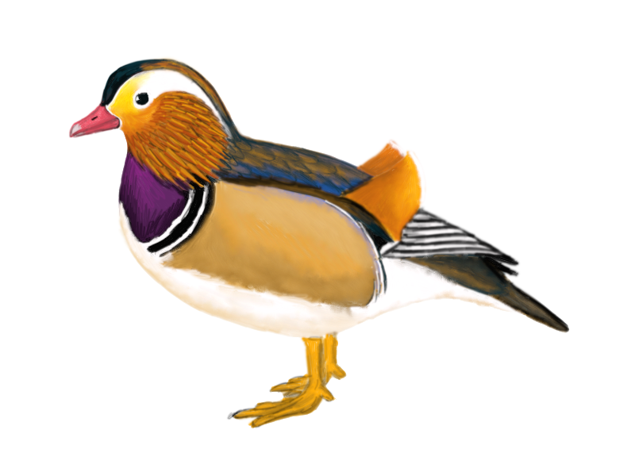

Aix galericulata

Mandarin Duck

USNM 622444

GCA_024635365.1

X

X

X

X

X

X

X

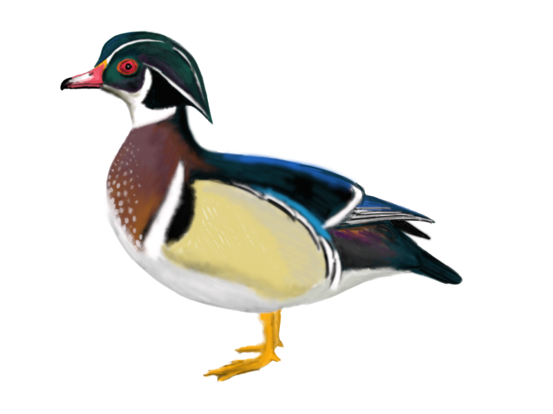

Aix sponsa

Wood Duck

MCZ:Orn:347504

GCA_032270905.1

X

X

X

X

X

X

X

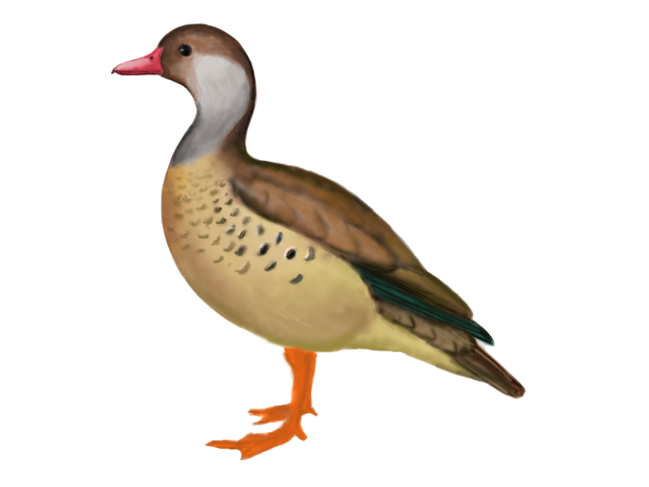

Amazonetta brasiliensis

Brazilian Teal

USNM 631047

X

X

X

X

X

X

X

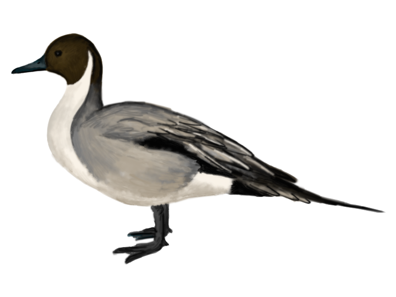

Anas acuta

Northern Pintail

MCZ:Orn:341895

GCA_963932015.1

X

X

X

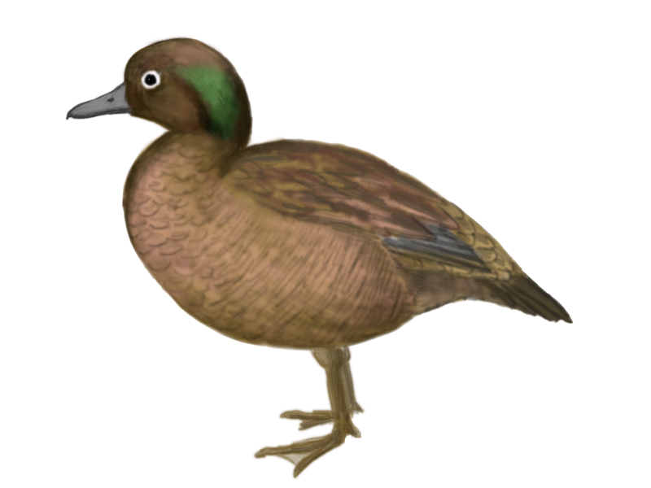

Anas aucklandica

Auckland Islands Teal

UMZC:Vertebrates:12/Ana/42/a/8-10

X

X

X

X

X

X

X

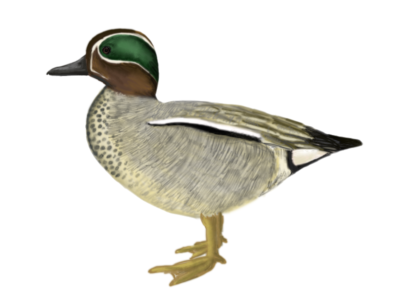

Anas crecca

Green-winged Teal

MCZ:Orn:347036

X

X

X

X

X

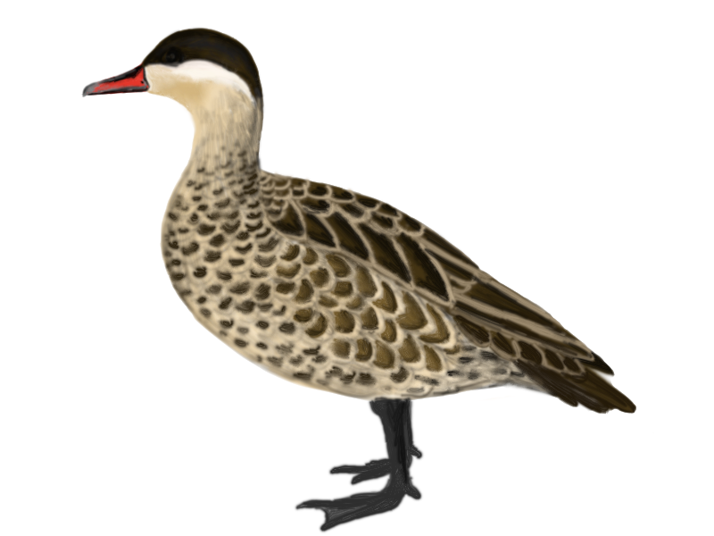

Anas erythrorhyncha

Red-billed Duck

NHMUK:Zoo:S/1952.1.159

X

X

X

X

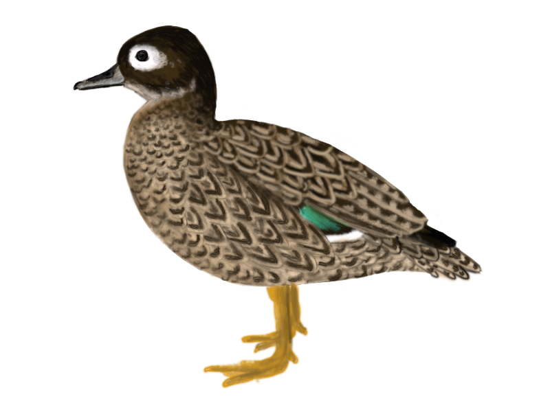

Anas laysanensis

Laysan Duck

MCZ:Orn:347544

X

X

X

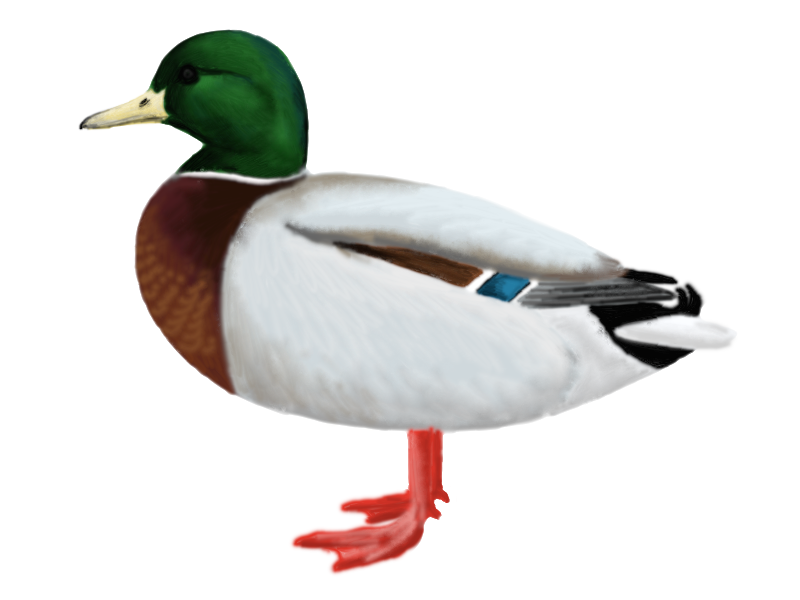

Anas platyrhynchos

Mallard

MCZ:Orn:347156

GCA900411745.1

X

X

X

X

X

X

X

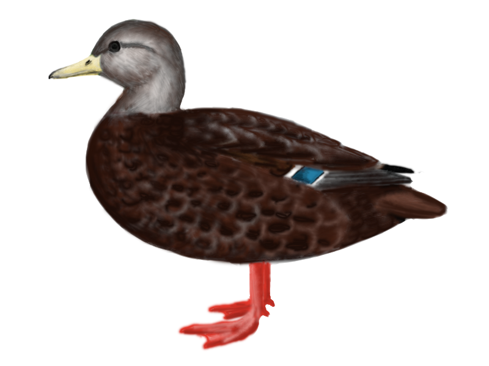

Anas rubripes

American Black Duck

MCZ:Orn:337845

X

X

X

X

X

X

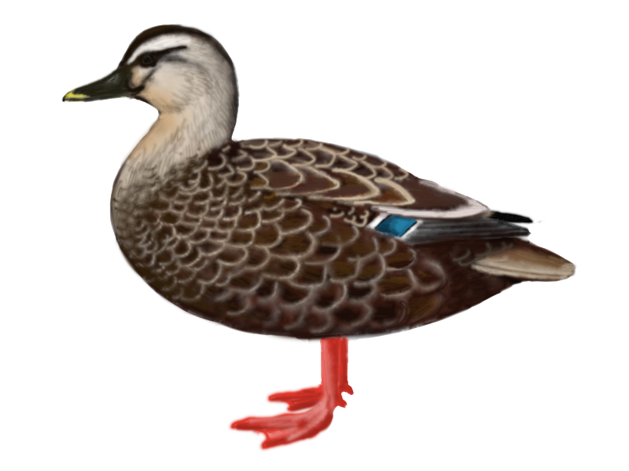

Anas zonorhyncha

Eastern Spot-billed Duck

USNM 633481

GCA_002224875.1

X

X

X

X

X

X

X

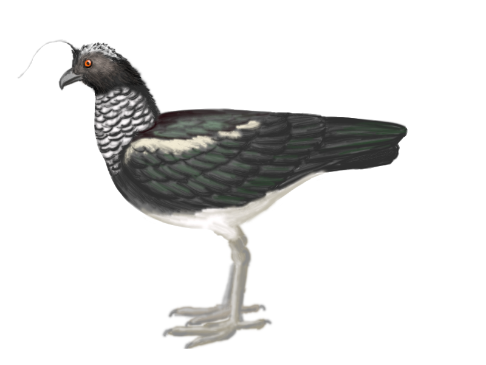

Anhima cornuta

Horned Screamer

MCZ:Orn:346993

GCA_013399475.1

X

X

X

X

X

X

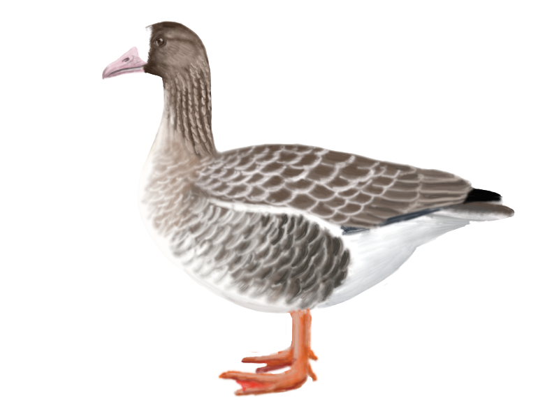

Anser albifrons

Greater White-fronted Goose

NHMUK:Zoo:1895.2.6.8

X

X

X

X

X

X

X

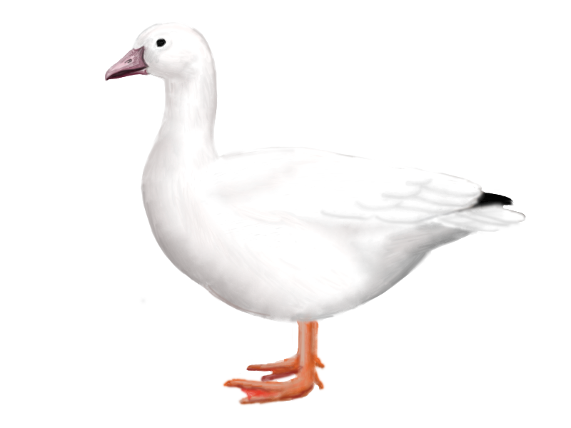

Anser caerulescens

Snow Goose

MCZ:Orn:341885

X

X

X

X

X

X

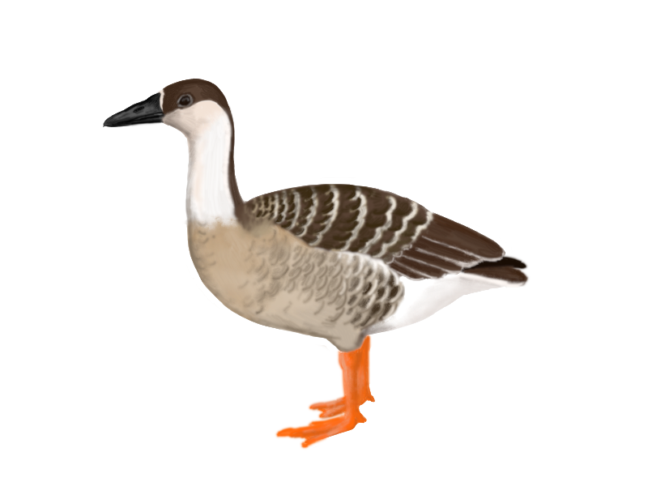

Anser cygnoides

Swan Goose

USNM 19637

GCA_026259575.1

X

X

X

X

X

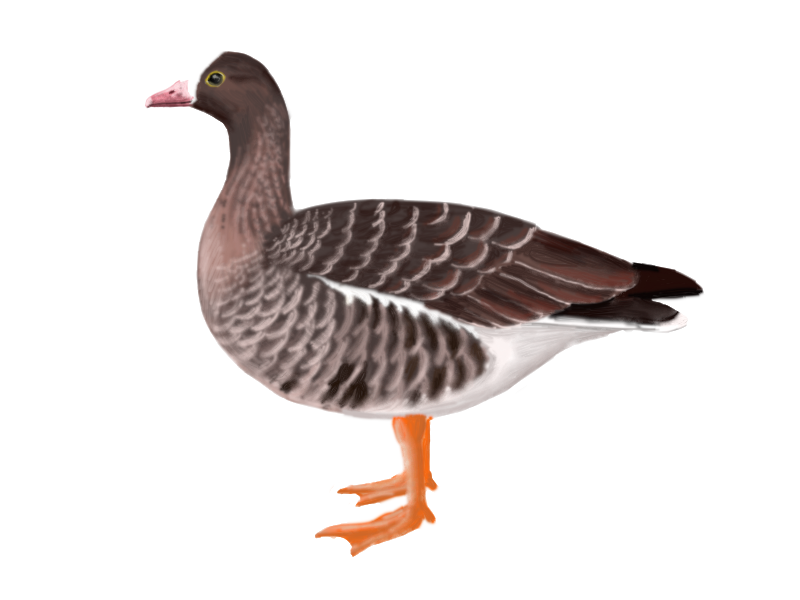

Anser erythropus

Lesser White-fronted Goose

MCZ:Orn:340330

X

X

X

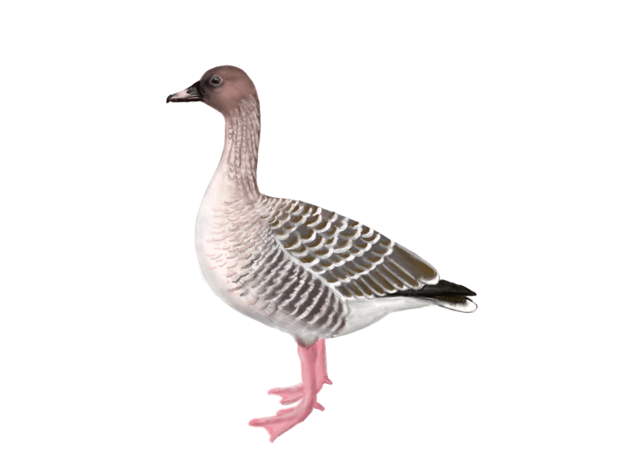

Anser fabalis

Taiga Bean-Goose

MCZ:Orn:340262

GCA_002592135.1

X

X

X

X

X

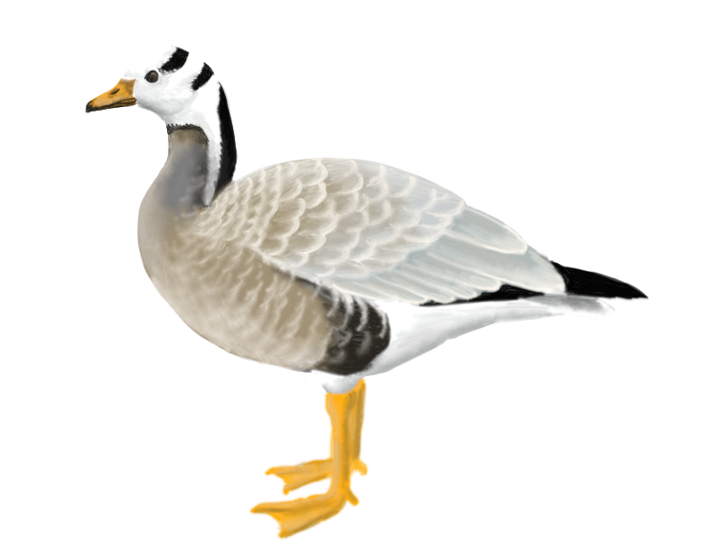

Anser indicus

Bar-headed Goose

USNM 557494

GCA_025583725.1

X

X

X

X

X

X

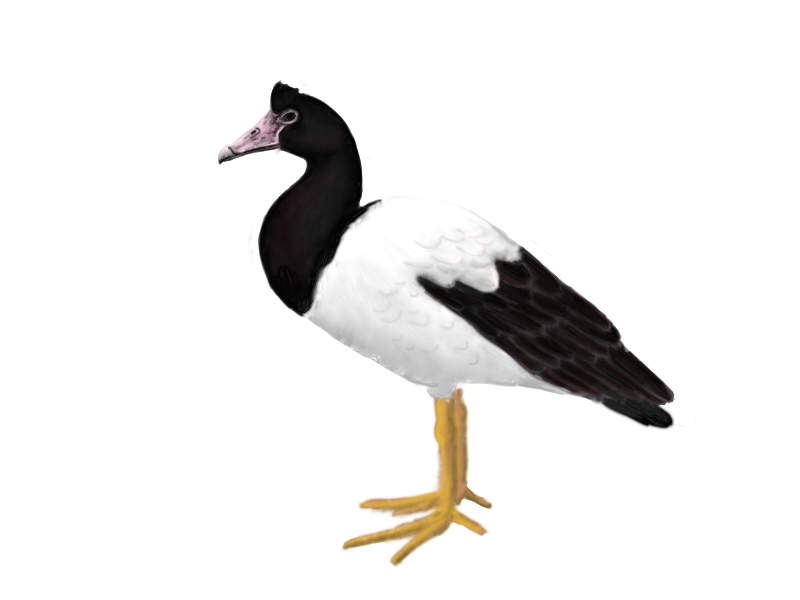

Anseranas semipalmata

Magpie Goose

NHMUK:Zoo:1852.7.22.1

GCA_013399115.1

X

X

X

X

X

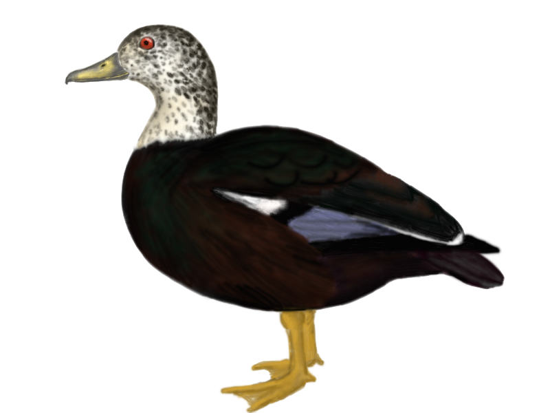

Asarcornis scutulata

White-winged Duck

USNM 612610

GCA_013398475.1

X

X

X

X

X

X

X

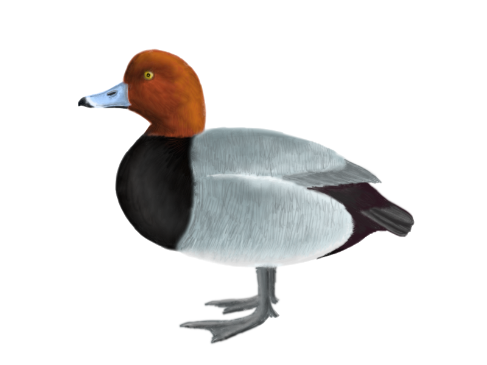

Aythya americana

Redhead

MCZ:Orn:346918

X

X

X

X

X

X

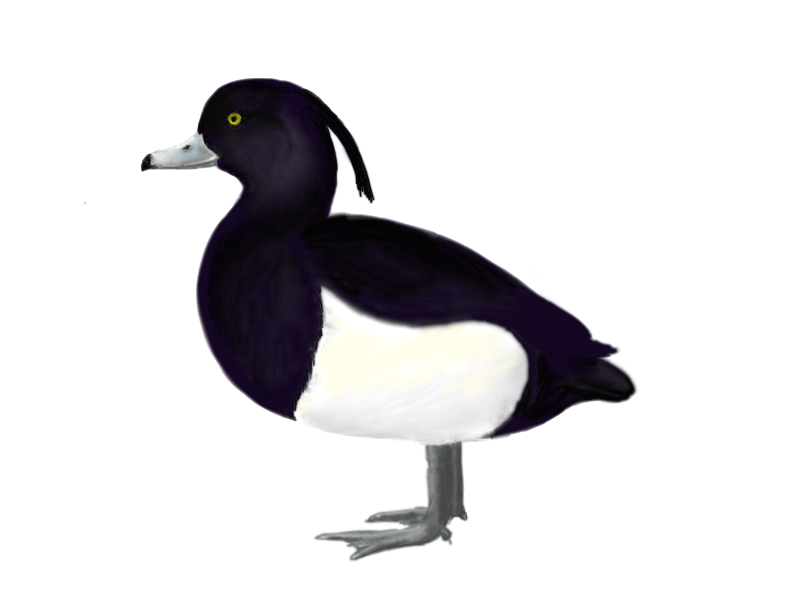

Aythya fuligula

Tufted Duck

USNM 641850

GCA_009819795.1

X

X

X

X

X

X

X

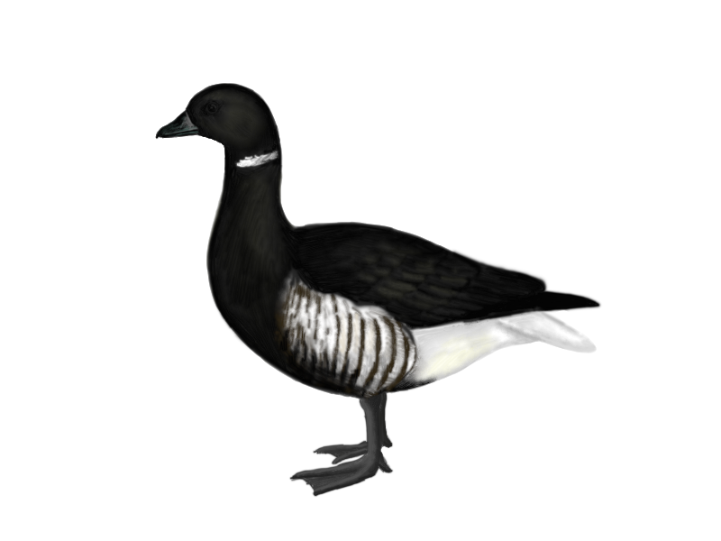

Branta bernicla

Brant

MCZ:Orn:336993

X

X

X

X

X

X

X

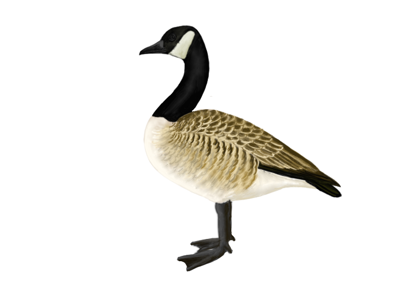

Branta canadensis

Canada Goose

MCZ:Orn:346738

GCA_006130075.1

X

X

X

X

X

X

X

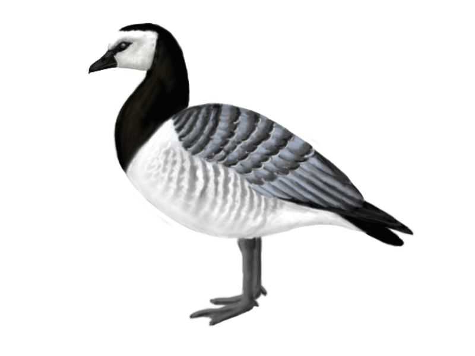

Branta leucopsis

Barnacle Goose

MCZ:Orn:346732

X

X

X

X

X

X

X

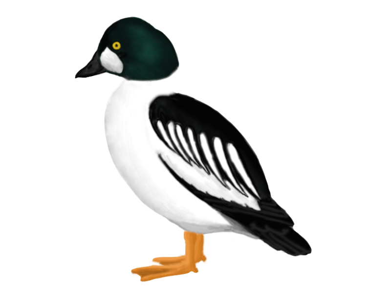

Bucephala clangula

Common Goldeneye

MCZ:Orn:347155

X

X

X

X

X

X

X

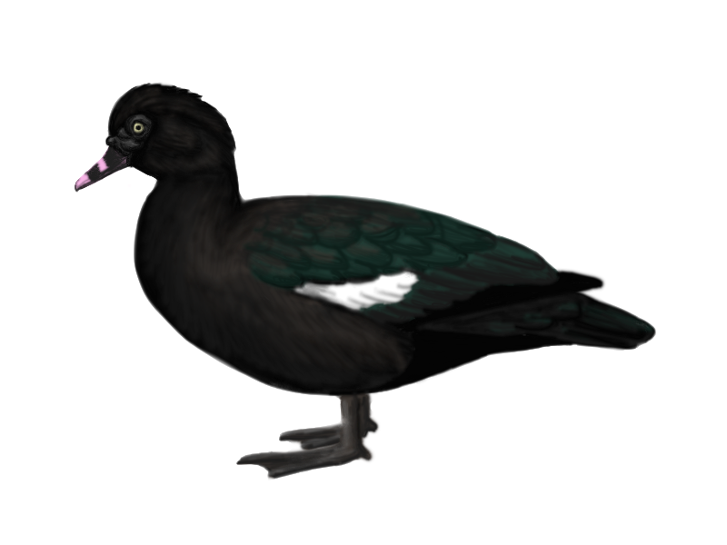

Cairina moschata

Muscovy Duck

MCZ:Orn:348425

GCA_018104995.1

X

X

X

X

X

X

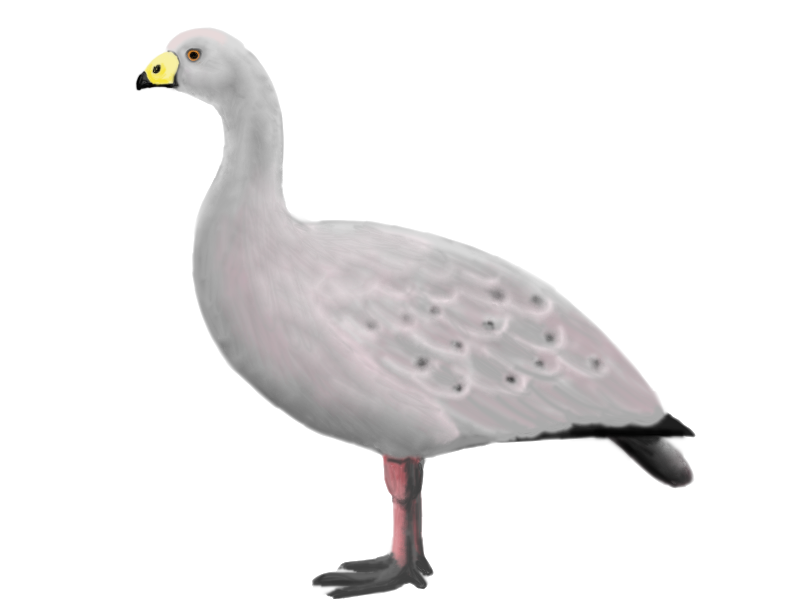

Cereopsis novaehollandiae

Cape Barren Goose

MCZ:Orn:347095

X

X

X

X

X

X

X

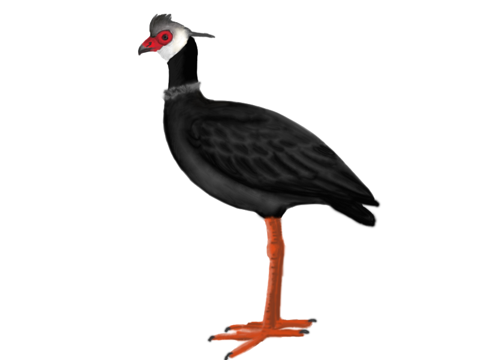

Chauna chavaria

Northern Screamer

MCZ:Orn:340307

X

X

X

X

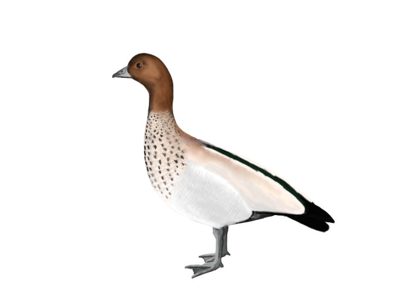

Chenonetta jubata

Maned Duck

MCZ:Orn:339522